# MATH1005 Project 2

Enterococci bacteria levels in the water of Sydney Northern Beaches during the year 2018

SID: 490185362

University of Sydney | MATH1005 | February Intensive 2021

# 1 Executive Summary

This report aims to investigate differences in Enterococci levels at Sydney’s Northern Beaches. We determined which site had the highest and lowest Enterococci levels and its variation throughout 2018 by comparing the box plot’s medians and IQR’s. Next, we examined the impact of seasonal changes on the Enterococci levels.

# 2 Full Report

## 2.1 Initial Data Analysis (IDA)

### 2.1.1 Source of Data

```r
data = read.csv("beaches.csv",na.strings = c("-9"), header = TRUE)
Table= read.csv("Table_of_variables.csv", header = TRUE)
```

### 2.1.2 Complexity of Data

```r
head(data, n=3 )  #Returns the first three rows of the data
```

```
##   X BeachId                        Region                  Council         Site
## 1 1       4 Sydney Northern Ocean Beaches Northern Beaches Council Avalon Beach
## 2 2       4 Sydney Northern Ocean Beaches Northern Beaches Council Avalon Beach
## 3 3       4 Sydney Northern Ocean Beaches Northern Beaches Council Avalon Beach
##   Longitude  Latitude       Date Enterococci..cfu.100ml.    Month Day.of.Week
## 1  151.3324 -33.63587 2018-01-25                       6  January    Thursday
## 2  151.3324 -33.63587 2018-02-07                       0 February   Wednesday
## 3  151.3324 -33.63587 2018-02-19                       1 February      Monday
```

```r
dim(data)  #Returns the dimension of data as rows and columns
```

```
## [1] 1276   11
```

```r
class(data) #Represent the type or style of data
```

```
## [1] "data.frame"
```

```r
names(data)  #Returns the names of columns or variables
```

```
##  [1] "X"                       "BeachId"
##  [3] "Region"                  "Council"
##  [5] "Site"                    "Longitude"
##  [7] "Latitude"                "Date"
##  [9] "Enterococci..cfu.100ml." "Month"
## [11] "Day.of.Week"
```

```r
data$Region=as.factor(data$Region)  #Changing all the character arguments to factors
data$BeachId=as.integer(data$BeachId)
data$Council=as.factor(data$Council)
data$Site=as.factor(data$Site)
data$Date=as.factor(data$Date)
data$Enterococci..cfu.100ml.=as.integer(as.factor(data$Enterococci..cfu.100ml.))
data$Month=as.factor(data$Month)
data$Day.of.Week=as.factor(data$Day.of.Week)
str(data) #Returns the internal structure of the data
```

```
## 'data.frame':    1276 obs. of  11 variables:
##  $ X                      : int  1 2 3 4 5 6 7 8 9 10 ...
##  $ BeachId                : int  4 4 4 4 4 4 4 4 4 4 ...
##  $ Region                 : Factor w/ 1 level "Sydney Northern Ocean Beaches": 1 1 1 1 1 1 1 1 1 1 ...
##  $ Council                : Factor w/ 1 level "Northern Beaches Council": 1 1 1 1 1 1 1 1 1 1 ...
##  $ Site                   : Factor w/ 22 levels "Avalon Beach",..: 1 1 1 1 1 1 1 1 1 1 ...
##  $ Longitude              : num  151 151 151 151 151 ...
##  $ Latitude               : num  -33.6 -33.6 -33.6 -33.6 -33.6 ...
##  $ Date                   : Factor w/ 59 levels "2018-01-03","2018-01-09",..: 6 8 10 5 7 13 14 48 51 52 ...
##  $ Enterococci..cfu.100ml.: int  72 1 2 2 22 1 45 61 1 1 ...
##  $ Month                  : Factor w/ 12 levels "April","August",..: 5 4 4 5 4 8 8 11 11 10 ...
##  $ Day.of.Week            : Factor w/ 6 levels "Friday","Monday",..: 4 6 2 1 4 4 6 5 6 6 ...
```

### 2.1.3 Classification of Variables

```r
library(formattable) #A table of the variables in the data with their description and classification
formattable(Table,
            align =c("l","l","c","c"),
            list(`Indicator Name` = formatter(
            "span", style = ~ style(color = "grey",font.weight = "bold"))))
```

| Variable | Description | R.Classification. | Changed.To |
| --- | --- | --- | --- |
| Beach ID | Identification number of Site | Number | Integer |
| Region | Sydney Northern Ocean Beaches | Character | Factor |
| Council | Northern Beaches Council | Character | Factor |
| Site | Official name of the beach | Character | Factor |
| Longitude | Location of which sample was taken | Number | Unchanged |
| Latitude | Location of which sample was taken | Number | Unchnaged |
| Date | Date of which sample was taken | Character | Factor |
| Enterococci (cfu/100ml) | Measurement of bacteria level in colony-forming per 100mL | Character | Integer |
| Month | Month of which sample was taken | Character | Factor |

### 2.1.4 Summary

#### 2.1.4.1 Source of Data :

The Enterococci bacteria data of Sydney Northern Beaches were collected under the Beachwatch Water Quality Program and recorded by the NSW Government Office of Environment and Heritage [1]. The data provides an assessment of Enterococci bacterial level in the water and how suitable each site is for swimming during 2018. The data set analysis will help individuals make their decisions about when and where to swim. It will also help to investigate community concerns surrounding potential fecal or other sewage contamination in polluted water.

Enterococci bacteria are rarely present in clean water, and it mostly appears due to the presence of fecal material by humans or animals [2]. This type of bacteria has been linked to several diseases affecting humans’ overall health [2]. Moreover, It is negatively affecting sports lovers and the economic values of the aquatic resources. Therefore, possible stakeholders may include other governments and scientists who could be interested in doing future research on the Enterococci and its impact on society. This data set could also be used to develop or implement programs by private sewage disposal companies in order to reduce and solve the issue of contamination in beaches due to the Enterococci level in the water.

#### 2.1.4.3 Reliability and Limitations:

This data set is reliable since it does not contain any missing data, and it has a large sample size of 1276 throughout 22 different beaches in the region. Hence, this data set is very suitable for monthly analysis to distinguish any Enterococci level difference throughout the seasons. However, the data set has limitations since there might be other factors that affect the Enterococci level, such as climate, the geography of the site, industrial presence, population and the area of each beach. Also, the data is not appropriate for long term analysis as it just includes sample taken during the year 2018. Other factors that might affect scientists’ analysis are a precise hourly timed measurement and the method used in the laboratory to test the Enterococci level in the samples.

## 2.2 Research Question 1

Which swimming site of The Northern Beaches Council area in the Northern Beaches region of Sydney has the highest Enterococci bacteria level? And is there a particular month(s) where the Enterococci bacteria level was high across most beaches?

### 2.2.1 Graphical summary

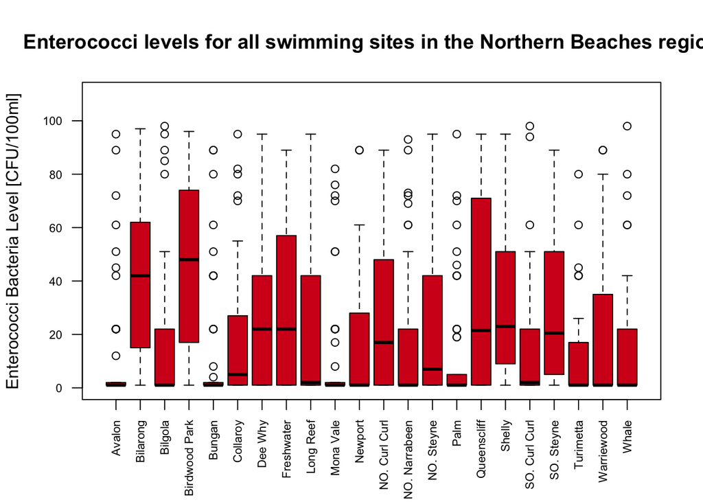

```r
Enterococci <- data[c("Site","Month","Enterococci..cfu.100ml.")] # Creating subsets of the data
 # Isolating the level of Enterococci Bacteria at each swimming site
E_1 = Enterococci$Enterococci..cfu.100ml.[Enterococci$Site =="Avalon Beach"]
E_2 = Enterococci$Enterococci..cfu.100ml.[Enterococci$Site =="Bilarong Reserve (Narrabeen Lagoon)"]
E_3 = Enterococci$Enterococci..cfu.100ml.[Enterococci$Site =="Bilgola Beach"]
E_4 = Enterococci$Enterococci..cfu.100ml.[Enterococci$Site =="Birdwood Park (Narrabeen Lagoon)"]
E_5 = Enterococci$Enterococci..cfu.100ml.[Enterococci$Site =="Bungan Beach"]
E_6 = Enterococci$Enterococci..cfu.100ml.[Enterococci$Site =="Collaroy Beach"]
E_7 = Enterococci$Enterococci..cfu.100ml.[Enterococci$Site =="Dee Why Beach"]
E_8 = Enterococci$Enterococci..cfu.100ml.[Enterococci$Site =="Freshwater Beach"]
E_9 = Enterococci$Enterococci..cfu.100ml.[Enterococci$Site =="Long Reef Beach"]
E_10 = Enterococci$Enterococci..cfu.100ml.[Enterococci$Site =="Mona Vale Beach"]
E_11 = Enterococci$Enterococci..cfu.100ml.[Enterococci$Site =="Newport Beach"]
E_12 = Enterococci$Enterococci..cfu.100ml.[Enterococci$Site =="North Curl Curl Beach"]
E_13 = Enterococci$Enterococci..cfu.100ml.[Enterococci$Site =="North Narrabeen Beach"]
E_14 = Enterococci$Enterococci..cfu.100ml.[Enterococci$Site =="North Steyne Beach"]
E_15 = Enterococci$Enterococci..cfu.100ml.[Enterococci$Site =="Palm Beach"]
E_16 = Enterococci$Enterococci..cfu.100ml.[Enterococci$Site =="Queenscliff Beach"]
E_17 = Enterococci$Enterococci..cfu.100ml.[Enterococci$Site =="Shelly Beach (Manly)"]
E_18 = Enterococci$Enterococci..cfu.100ml.[Enterococci$Site =="South Curl Curl Beach"]
E_19 = Enterococci$Enterococci..cfu.100ml.[Enterococci$Site =="South Steyne Beach"]
E_20 = Enterococci$Enterococci..cfu.100ml.[Enterococci$Site =="Turimetta Beach"]
E_21 = Enterococci$Enterococci..cfu.100ml.[Enterococci$Site =="Warriewood Beach"]
E_22 = Enterococci$Enterococci..cfu.100ml.[Enterococci$Site =="Whale Beach"]
#names of each swimming site
Beaches = c(" Avalon Beach","Bilarong Reserve","Bilgola Beach","Birdwood Park","Bungan Beach","Collaroy Beach","Dee Why Beach","Freshwater Beach","Long Reef Beach","Mona Vale Beach","Newport Beach","North Curl Beach","North Narrabeen Beach","North Steyne Beach","Palm Beach","Queenscliff Beach","Shelly Beach","South Curl Beach","South Steyne Beach","Turimetta Beach","Warriewood Beach","Whale Beach")
Beache= c(" Avalon","Bilarong","Bilgola","Birdwood Park","Bungan","Collaroy","Dee Why","Freshwater","Long Reef","Mona Vale","Newport","NO. Curl Curl","NO. Narrabeen","NO. Steyne","Palm","Queenscliff","Shelly","SO. Curl Curl","SO. Steyne","Turimetta","Warriewood","Whale")
#Box plot comparing the  Enterococci Bacteria level at each beach in the Northern Beaches region of Sydney
boxplot(E_1,E_2,E_3,E_4,E_5,E_6,E_7,E_8,E_9,E_10,E_11,E_12,E_13,E_14,E_15,E_16,E_17,E_18,E_19,E_20,E_21,E_22,
       ylim=c(0,110),names=Beache,las=2,horizontal =F,col="#D41C1C",cex.axis=0.7,
       ylab="Enterococci Bacteria Level [CFU/100ml]",
       main="Enterococci levels for all swimming sites in the Northern Beaches region")
```

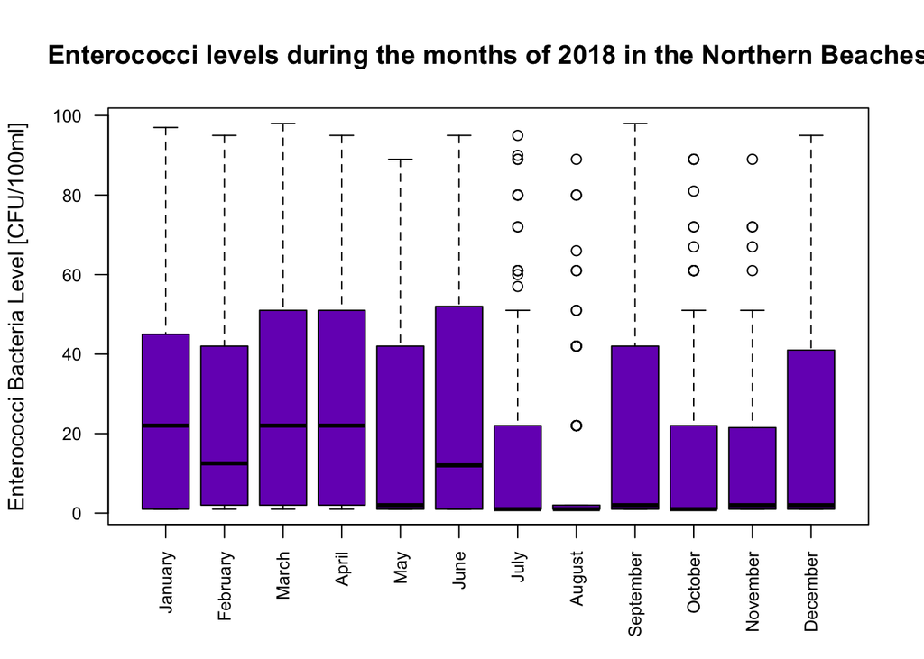

```r
 # Isolating the level of Enterococci Bacteria at of each month of 2018
one_M = Enterococci$Enterococci..cfu.100ml.[Enterococci$Month =="January"]
two_M = Enterococci$Enterococci..cfu.100ml.[Enterococci$Month =="February"]
three_M = Enterococci$Enterococci..cfu.100ml.[Enterococci$Month =="March"]
four_M = Enterococci$Enterococci..cfu.100ml.[Enterococci$Month =="April"]
five_M = Enterococci$Enterococci..cfu.100ml.[Enterococci$Month =="May"]
six_M = Enterococci$Enterococci..cfu.100ml.[Enterococci$Month =="June"]
seven_M = Enterococci$Enterococci..cfu.100ml.[Enterococci$Month =="July"]
eight_M = Enterococci$Enterococci..cfu.100ml.[Enterococci$Month =="August"]
nine_M = Enterococci$Enterococci..cfu.100ml.[Enterococci$Month =="September"]
ten_M = Enterococci$Enterococci..cfu.100ml.[Enterococci$Month =="October"]
eleven_M = Enterococci$Enterococci..cfu.100ml.[Enterococci$Month =="November"]
twelve_M = Enterococci$Enterococci..cfu.100ml.[Enterococci$Month =="December"]
Month_name=c("January","February","March","April","May","June","July","August","September","October","November","December")
#Box plot comparing the Enterococci Bacteria level across all months of 2018 in the Northern Beaches region of Sydney
boxplot(one_M,two_M,three_M,four_M,five_M,six_M,seven_M,eight_M,nine_M,ten_M,eleven_M,twelve_M,
       names=Month_name,las=2,horizontal = F,col="#7715BF",cex.axis=0.8,
       ylab="Enterococci Bacteria Level [CFU/100ml]",
       main="Enterococci levels during the months of 2018 in the Northern Beaches")
```

### 2.2.2 Numerical summary

```r
# summary(Enterococci)
# Median and interquartile range (IQR) of Enterococci Bacteria level at  swimming site 1
median(E_1)
```

```
## [1] 1
```

```r
IQR(E_1)
```

```
## [1] 1
```

```r
# Median and interquartile range (IQR) of Enterococci Bacteria level at  swimming site 2
median(E_2)
```

```
## [1] 42
```

```r
IQR(E_2)
```

```
## [1] 46.25
```

```r
# Median and interquartile range (IQR) of Enterococci Bacteria level at  swimming site 3
median(E_3)
```

```
## [1] 1
```

```r
IQR(E_3)
```

```
## [1] 19.75
```

```r
# Median and interquartile range (IQR) of Enterococci Bacteria level at  swimming site 4
median(E_4)
```

```
## [1] 48
```

```r
IQR(E_4)
```

```
## [1] 56
```

```r
# Median and interquartile range (IQR) of Enterococci Bacteria level at  swimming site 5
median(E_5)
```

```
## [1] 1
```

```r
IQR(E_5)
```

```
## [1] 1
```

```r
# Median and interquartile range (IQR) of Enterococci Bacteria level at  swimming site 6
median(E_6)
```

```
## [1] 5
```

```r
IQR(E_6)
```

```
## [1] 24.75
```

```r
# Median and interquartile range (IQR) of Enterococci Bacteria level at  swimming site 7
median(E_7)
```

```
## [1] 22
```

```r
IQR(E_7)
```

```
## [1] 41
```

```r
# Median and interquartile range (IQR) of Enterococci Bacteria level at  swimming site 8
median(E_8)
```

```
## [1] 22
```

```r
IQR(E_8)
```

```
## [1] 54.25
```

```r
# Median and interquartile range (IQR) of Enterococci Bacteria level at  swimming site 9
median(E_9)
```

```
## [1] 2
```

```r
IQR(E_9)
```

```
## [1] 41
```

```r
# Median and interquartile range (IQR) of Enterococci Bacteria level at  swimming site 10
median(E_10)
```

```
## [1] 1
```

```r
IQR(E_10)
```

```
## [1] 1
```

```r
# Median and interquartile range (IQR) of Enterococci Bacteria level at  swimming site 11
median(E_11)
```

```
## [1] 1
```

```r
IQR(E_11)
```

```
## [1] 25.5
```

```r
# Median and interquartile range (IQR) of Enterococci Bacteria level at  swimming site 12
median(E_12)
```

```
## [1] 17
```

```r
IQR(E_12)
```

```
## [1] 46.75
```

```r
# Median and interquartile range (IQR) of Enterococci Bacteria level at  swimming site 13
median(E_13)
```

```
## [1] 1
```

```r
IQR(E_13)
```

```
## [1] 20.75
```

```r
# Median and interquartile range (IQR) of Enterococci Bacteria level at  swimming site 14
median(E_14)
```

```
## [1] 7
```

```r
IQR(E_14)
```

```
## [1] 39
```

```r
# Median and interquartile range (IQR) of Enterococci Bacteria level at  swimming site 15
median(E_15)
```

```
## [1] 1
```

```r
IQR(E_15)
```

```
## [1] 3.25
```

```r
# Median and interquartile range (IQR) of Enterococci Bacteria level at  swimming site 16
median(E_16)
```

```
## [1] 21.5
```

```r
IQR(E_16)
```

```
## [1] 67.25
```

```r
# Median and interquartile range (IQR) of Enterococci Bacteria level at  swimming site 17
median(E_17)
```

```
## [1] 23
```

```r
IQR(E_17)
```

```
## [1] 41.5
```

```r
# Median and interquartile range (IQR) of Enterococci Bacteria level at  swimming site 18
median(E_18)
```

```
## [1] 2
```

```r
IQR(E_18)
```

```
## [1] 21
```

```r
# Median and interquartile range (IQR) of Enterococci Bacteria level at  swimming site 19
median(E_19)
```

```
## [1] 20.5
```

```r
IQR(E_19)
```

```
## [1] 46
```

```r
# Median and interquartile range (IQR) of Enterococci Bacteria level at  swimming site 20
median(E_20)
```

```
## [1] 1
```

```r
IQR(E_20)
```

```
## [1] 15.5
```

```r
# Median and interquartile range (IQR) of Enterococci Bacteria level at  swimming site 21
median(E_21)
```

```
## [1] 1
```

```r
IQR(E_21)
```

```
## [1] 32.75
```

```r
# Median and interquartile range (IQR) of Enterococci Bacteria level at  swimming site 22
median(E_22)
```

```
## [1] 1
```

```r
IQR(E_22)
```

```
## [1] 19.25
```

```r
All_sites= c( median(E_1),median(E_2),median(E_3),median(E_4),median(E_5),median(E_6),median(E_7),median(E_8),median(E_9),median(E_10),median(E_11),median(E_12),median(E_13),median(E_14),median(E_15),median(E_16),median(E_17),median(E_18),median(E_19),median(E_20),median(E_21),median(E_22))
max_1=max(All_sites)
```

```r
# Median and interquartile range (IQR) of Enterococci Bacteria level during JAN of 2018 for all swimming site
median(one_M)
```

```
## [1] 22
```

```r
IQR(one_M)
```

```
## [1] 43.75
```

```r
# Median and interquartile range (IQR) of Enterococci Bacteria level during FEB of 2018 for all swimming site
median(two_M)
```

```
## [1] 12.5
```

```r
IQR(two_M)
```

```
## [1] 40
```

```r
# Median and interquartile range (IQR) of Enterococci Bacteria level during MAR of 2018 for all swimming site
median(three_M)
```

```
## [1] 22
```

```r
IQR(three_M)
```

```
## [1] 48.25
```

```r
# Median and interquartile range (IQR) of Enterococci Bacteria level during APR of 2018 for all swimming site
median(four_M)
```

```
## [1] 22
```

```r
IQR(four_M)
```

```
## [1] 47.5
```

```r
# Median and interquartile range (IQR) of Enterococci Bacteria level during MAY of 2018 for all swimming site
median(five_M)
```

```
## [1] 2
```

```r
IQR(five_M)
```

```
## [1] 41
```

```r
# Median and interquartile range (IQR) of Enterococci Bacteria level during JUN of 2018 for all swimming site
median(six_M)
```

```
## [1] 12
```

```r
IQR(six_M)
```

```
## [1] 51
```

```r
# Median and interquartile range (IQR) of Enterococci Bacteria level during JUL of 2018 for all swimming site
median(seven_M)
```

```
## [1] 1
```

```r
IQR(seven_M)
```

```
## [1] 20.25
```

```r
# Median and interquartile range (IQR) of Enterococci Bacteria level during AUG of 2018 for all swimming site
median(eight_M)
```

```
## [1] 1
```

```r
IQR(eight_M)
```

```
## [1] 1
```

```r
# Median and interquartile range (IQR) of Enterococci Bacteria level during SEP of 2018 for all swimming site
median(nine_M)
```

```
## [1] 2
```

```r
IQR(nine_M)
```

```
## [1] 41
```

```r
# Median and interquartile range (IQR) of Enterococci Bacteria level during OCT of 2018 for all swimming site
median(ten_M)
```

```
## [1] 1
```

```r
IQR(ten_M)
```

```
## [1] 21
```

```r
# Median and interquartile range (IQR) of Enterococci Bacteria level during NOV of 2018 for all swimming site
median(eleven_M)
```

```
## [1] 2
```

```r
IQR(eleven_M)
```

```
## [1] 20.25
```

```r
# Median and interquartile range (IQR) of Enterococci Bacteria level during DEC of 2018 for all swimming site
median(twelve_M)
```

```
## [1] 2
```

```r
IQR(twelve_M)
```

```
## [1] 39.5
```

```r
All_months= c(median(one_M),median(two_M),median(three_M),median(four_M),median(five_M),median(six_M),median(seven_M),median(eight_M),median(nine_M),median(ten_M),median(eleven_M),median(twelve_M))
max_2=max(All_months) #22
```

### 2.2.3 Graphical summary Analysis

The first box plot represents a comparison of Enterococci levels for all swimming sites. The second box plot represents a comparison of Enterococci levels for all months in 2018. We noticed strong outliers for both plots and a wide spread of data in the first plot. Other very large outliers in the first plot have been eliminated for clarity.

### 2.2.4 Numerical summary analysis

Median and interquartile range (IQR) were used in place of mean and standard deviation (SD), as our data is skewed and due to the presence of many strong outliers.

**Data reported as (median, IQR)**

**—Enterococci bacteria level for each swimming site—**

Avalon and Mona Vale beaches have the lowest median and IQR. Hence, they were suitable for swimming

### 2.2.5 Summary:

To summarize, we found that Avalon and Mona Vale beaches have the lowest Enterococci level. The water at Birdwood Park is most polluted, and the site not safe for swimming. Next, we found a high level of fecal contamination in the water in all sites in the Northern Beaches region of Sydney during summer and autumn. It is safest to swim during winter and spring.

Researchers directly linked the high concentration of Enterococci in polluted water and increased risk of illness for swimmers, particularly those with lower immune function [4]. It has been suggested that other factors lead to higher concentrations of Enterococci, such as rainfall seasons and tides, which supports the large variations we found in Enterococci level between summer and winter [4]. Researchers also suggest a measuring Enterococci on hands and skin will help understand post-collection stored water contamination and water contamination in general. However, a limitation is that there are no current regulations or standard methods for measuring Enterococci on the skin. However, further work needs to be done to prove this idea [4].

## 2.3 Research Question 2

Does the change in season affect the Enterococci level in a swimming site?

### 2.3.1 Comparative Boxplots

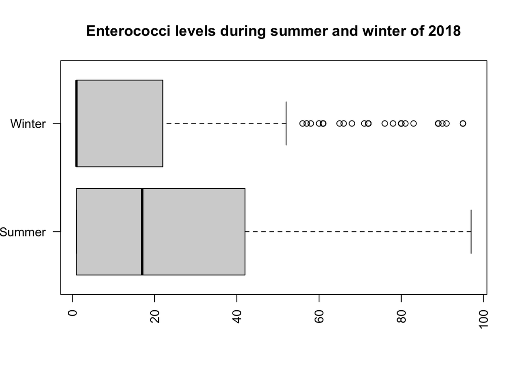

```r
summer=Enterococci[(Enterococci$Month=="December"|Enterococci$Month=="January"|Enterococci$Month=="February"),]   # summer months in Sydeny
winter=Enterococci[(Enterococci$Month=="June"|Enterococci$Month=="July"|Enterococci$Month=="August"),]  # winter months in Sydeny
boxplot(summer$Enterococci..cfu.100ml.,winter$Enterococci..cfu.100ml.,names=c("Summer","Winter"),las = 2,horizontal=T
,main="Enterococci levels during summer and winter of 2018")
```

### 2.3.2 Levene’s Test (Variance Test)

```r
library(car)
# Levene's Test for equality of variances
leveneTest( c(winter$Enterococci..cfu.100ml., summer$Enterococci..cfu.100ml.),
  factor(c(rep("winter",length(winter$Enterococci..cfu.100ml.)),
           rep("summer",length(summer$Enterococci..cfu.100ml.)))))
```

```
## Levene's Test for Homogeneity of Variance (center = median)
##        Df F value    Pr(>F)
## group   1  16.011 7.068e-05 ***
##       614
## ---
## Signif. codes:  0 '***' 0.001 '**' 0.01 '*' 0.05 '.' 0.1 ' ' 1
```

### 2.3.3 Welch 2-Sample T-Test

We will use the Welch 2-Sample T-Test to test for the difference in means of Enterococci levels during summer and winter of 2018 in the Northern Beaches region of Sydney since the 2 samples have unequal variance by the Levene’s Test.

```r
mu1=mean(summer$Enterococci..cfu.100ml.) # Mean of sample 1
mu2=mean(winter$Enterococci..cfu.100ml.)  # Mean of sample 2
n1=length(summer$Enterococci..cfu.100ml.) # Size of sample 1
n2=length(winter$Enterococci..cfu.100ml.) # Size of sample 2
sd1=sd(summer$Enterococci..cfu.100ml.) # Sample 1 standard deviation
sd2=sd(winter$Enterococci..cfu.100ml.) # Sample 2 standard deviation
se = sqrt(((sd1)^2/n1 + (sd2)^2/n2))  # Standard error
TestStat=(mu1-mu2-0)/se  # Test Statistic
numerator= (((sd1)^2/n1)+((sd2)^2/n2))^2
denominator1=(((sd1)^2/n1)^2) /(n1-1)
denominator2=(((sd2)^2/n2)^2) /(n2-1)
df= numerator/(denominator1+denominator2) # Degree of freedom
Pvalue =2*pt(abs(TestStat),608.16,lower.tail=F) # P-value
c(TestStat, Pvalue, df)
```

```
## [1] 3.992300e+00 7.343265e-05 6.081599e+02
```

```r
t.test(summer$Enterococci..cfu.100ml.,winter$Enterococci..cfu.100ml.,var.equal=F) #speedy way in R
```

```
##
##  Welch Two Sample t-test
##
## data:  summer$Enterococci..cfu.100ml. and winter$Enterococci..cfu.100ml.
## t = 3.9923, df = 608.16, p-value = 7.343e-05
## alternative hypothesis: true difference in means is not equal to 0
## 95 percent confidence interval:
##   4.604107 13.519269
## sample estimates:
## mean of x mean of y
##  25.80195  16.74026
```

### 2.3.4 Analysis

#### 2.3.4.1 Hypotheses $H_0$ vs. $H_1$

**—Null Hypotheses—**  
$H_0$: The mean of Enterococci levels in all swimming site is equal in both summer and winter seasons such that $\mu_1 = \mu_2$.

**—Alternative Hypotheses—**  
$H_1$: The mean of Enterococci levels in all swimming site is not equal in summer compared to winter season $\mu_1 \neq \mu_2$.

#### 2.3.4.2 Assumptions

**A1.** Both seasons are independent samples of each other. Hence, the first assumption is satisfied.

**A2.** Although the sample mean (sample sum) does not follow a normal distribution, the sample size is big enough for the central limit theorem to apply. Hence, the second assumption is satisfied.

**A3.** Using the Levene’s Test (Variance Test) to compare the two variances of winter and summer, we found the p-value to be $7.068 \times 10^{-5}$, which is less than the significance level of $0.05$. Hence, there is a significant difference between the two variances(spread). However, This assumption is satisfied by using the Welch 2-Sample T-Test.

#### 2.3.4.3 Test statistic

We will use the Test Statistic to measure the difference between summer and winter and what is expected based on $H_{0}$ : Test Statistic = $\frac{OV-EV}{\hat{SE}}$,

where the standard error is ${SE}=\sqrt{(\frac{S_1^2}{n_1}+\frac{S_2^2}{n_2})}$

and sample standard deviation is $S_{k}=\hat{SD_k}$ , $k=1,2$.

We substitute the values into the equations :  
Observed value = $\bar{x_1}-\bar{x_2}= 25.8-16.7=9.06$

Expected value = $0$ since our null hypothesis is that there is no difference in population means.

The sample size for both populations is equal such that $n_1=n_2=308$. The sample standard deviation is $SD_1= 29.5$ and $SD_2= 26.8$. We calculated the standard error to be ${SE}=2.27$. We substituted all the values and calculated the Test Statistic to be $3.99$. We obtained the degree of freedom using $\nu=\frac{(\frac{S_1^2}{n_1}+\frac{S_2^2}{n_2})^2}{\frac{ (\frac{S_1^2}{n_1})^2}{n_1-1}+\frac{(\frac{S_2^2}{n_2})^2}{n_2-1}}$ = $608.16$ .

Finally, we used the `t.test`function in R and obtained the exact values for the Test Statistic and degree of freedom.

#### 2.3.4.4 P-value

We found the p-value, which is the probability of $H_{0}$ being true equal to $7.343 \times 10^{-5}$ using both`pt` and `t.test` function in R.

$p = P(T > |$ Test Statistic $|)= 2 \times P(T > | 3.992|)= 7.343 \times 10^{-5} < 0.05$.

The convention is to reject the null hypothesis if $p<0.05$. Since the p-value is less than $0.05$, we do have enough evidence to reject the null hypothesis, and so the data does provide evidence that $\mu_1 \neq \mu_2$.

#### 2.3.4.5 Conclusion

**—Statistical Conclusion:—**

Mean values are statically different for winter and summer, which means that the Enterococci level increases in summer and decreases in winter. As the p-value < 0.05, we reject the null hypothesis. We also have the $95$% Confidence Interval for the mean difference $(4.60, 13.52)$, which does not contain the null hypothesis value of zero.

**—Scientific Conclusion:—**

Using the Welch 2-Sample T-Test, the data does not provide evidence that the Enterococci level is not affected by the change in seasons. This could be explained by the increase of Enterococci in the rainfall seasons(during summer) and the decrease in drier weather (during winter).

# 3 References

[1] Enterococci data download. (n.d.). Retrieved February 07, 2021, from https://www.environment.nsw.gov.au/beachapp/report_enterococci.aspx

[2] Indicators: Enterococci. (2016, August 16). Retrieved February 09, 2021, from https://www.epa.gov/national-aquatic-resource-surveys/indicators-enterococci

[3] State of the beaches 2018-2019 [PDF]. (n.d.). DEPARTMENT OF PLANNING, INDUSTRY & ENVIRONMENT. https://www.environment.nsw.gov.au/beachwatch

[4] Boehm AB, Sassoubre LM. Enterococci as Indicators of Environmental Fecal Contamination. 2014 Feb 5. In: Gilmore MS, Clewell DB, Ike Y, et al., editors. Enterococci: From Commensals to Leading Causes of Drug Resistant Infection [Internet]. Boston: Massachusetts Eye and Ear Infirmary; 2014-. Available from: https://www.ncbi.nlm.nih.gov/books/NBK190421/